# R 기초 통계 1 복습

# R 기초 통계 1일차

## Importing a data in R

- R을 이용하여 분석하기 위해선 데이터를 입력해야 하는데 그 방법이 두가지가 있다.
- c()함수와 data.frame()함수를 이용하여 R에 직접 데이터를 입력하기
- read_excel() 또는 read.csv(), read.table()를 통해 외부자료를 불러오기
- 먼저 데이터 프레임에 대해 살펴보면,

### 데이터 프레임

- R에서 자료를 처리하는 기본 구조이다.
- Excel의 스프레드시트라고 생각하면 된다.

[output not shown]

위의 자료를 R에 입력하여 분석해보자.

- c()함수를 이용하여 문자, 숫자에 맞게 자료를 생성한다.
- 생성된 자료를 data.frame() 함수로 묶으면 된다.
- 비가 관측된 지점은 파랑색으로, 그렇지 않은 지점은 검은색으로 표현하고자 한다면??
- ifelse(조건, 참일때, 거짓일때)를 만들면 된다.
- 현재 온도가 가장 높은 지점은 max() 함수를 이용하면 찾을 수 있다.

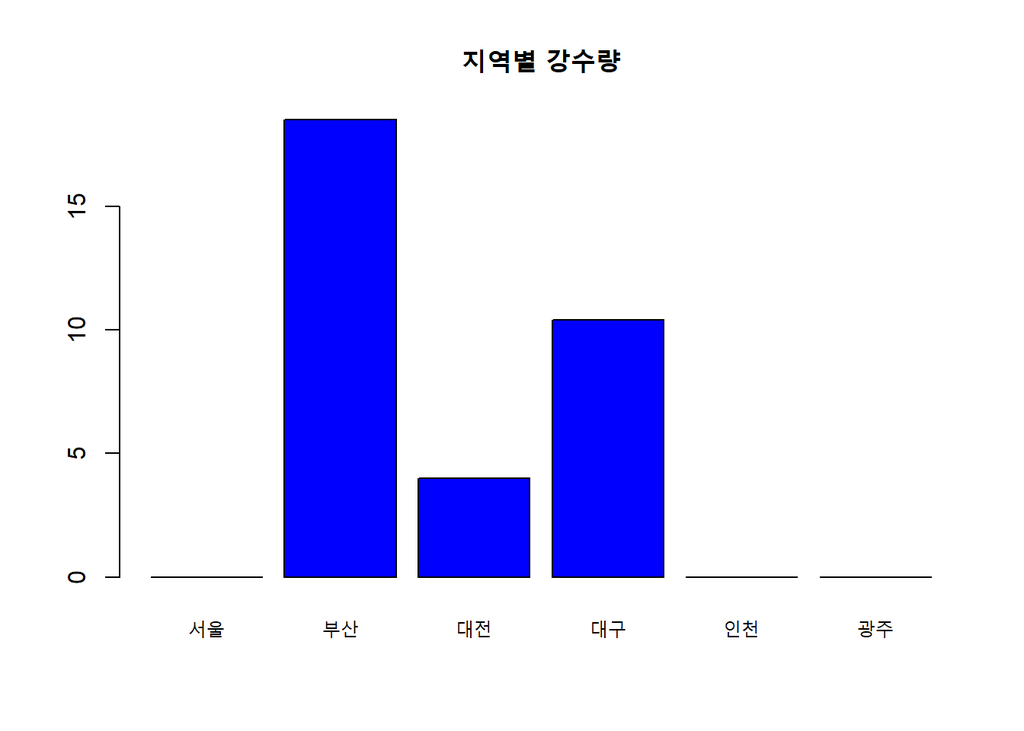

```r
stn <- c( "서울", "부산","대전","대구","인천","광주")
temp <- c(22.7,25.3,23.4,24.9,22.9,24.8)
prec <- c(0,18.5,4,10.4,0,0)
ws <- c(0.5,1.2,0.9,1.2,0.7,2.4)
rh <- c(89,97,96,97,85,84)

obs <- data.frame(stn,temp,prec,ws,rh)

obs$col <- ifelse(obs$prec>0,"blue","black")

barplot(obs$prec, names.arg=obs$stn, col=obs$col, main="지역별 강수량")
```

```r
obs$temp==max(obs$temp) #최고값 여부를 논리식으로 표현
```

```
## [1] FALSE  TRUE FALSE FALSE FALSE FALSE
```

```r
obs[obs$temp==max(obs$temp),] # index를 의미하는 중괄호에 넣자.
```

```
##    stn temp prec  ws rh  col
## 2 부산 25.3 18.5 1.2 97 blue
```

- 막대도표(barplot)은 데이터 시각화에 다시 다루겠습니다.

#### 팀문제 1. 뽀로로 친구들이 시험을 봤는데 시험 성적이 다음과 같다.

[figure not shown]

| id | math | eng | kor |
| --- | --- | --- | --- |
| 뽀로로 | 81 | 89 | 92 |
| 크롱 | 86 | 63 | 73 |
| 에디 | 98 | 75 | 86 |
| 포비 | 62 | 65 | 78 |
| 해리 | 86 | 95 | 93 |
| 루피 | 79 | 93 | 89 |
| —- | —- | —- | —- |

1. pororo라는 data.frame을 생성하세요.
2. total=math+eng+kor 입니다. 총점을 생성하세요.
3. avg = total/3입니다. 평균을 생성하세요.
4. 평균이 80점을 넘으면 합격, 그렇지 않으면 불합격이라고 합니다. 합격유무를 pass로 만드세요.
5. max()함수를 이용하여 총점이 높은 친구이름과 min()함수를 이용하여 총점이 낮은 친구이름을 찾으세요.

### 외부자료 불러오기 (excel, csv)

- excel 파일은 library(readxl)를 불러온 후 read_excel()함수로 불러오면 된다.
- csv 파일은 read.csv()파일로 불러오자.
- window는 choose.files()함수를 통해 파일을 대화상자를 통해 선택할 수 있다.
- 파일의 절대경로를 설정하면 대화상자를 이용하지 않고도 파일을 불러올 수 있다.
- 윈도우의 경우 주소를 복사하면 ↘ (back slash)가 있는데 R에서는 인식되지 않으므로 모두 /(slash)로 바꾸자.

```r
school.data <- read.csv("C:/Users/stats/Documents/R Base/baseR2/2019년_공시대상학교정보(전체).csv")

## Project Based Learning!
```

## Check the data after reading

- 자료를 불러왔으면 잘 불러졌는지 확인 해야한다.
- 불러온 자료를 확인하기 위한 함수로 dim(), head(), tail(), str(), View()가 있다.
- dim : 행과 열의 수 확인
- head : 자료의 앞부분 확인
- tail : 자료의 마지막 확인
- str : 자료의 구조 확인
- View : R viewer를 통해 자료 확인

```r
dim(school.data)
```

```
## [1] 12183    26
```

```r
head(school.data)
```

```
##         시도교육청                   지역교육청              지역
## 1 서울특별시교육청 서울특별시강남서초교육지원청 서울특별시 서초구
## 2 서울특별시교육청     서울특별시중부교육지원청 서울특별시 종로구
## 3 서울특별시교육청 서울특별시강남서초교육지원청 서울특별시 강남구
## 4 서울특별시교육청 서울특별시강남서초교육지원청 서울특별시 강남구
## 5 서울특별시교육청 서울특별시강남서초교육지원청 서울특별시 강남구
## 6 서울특별시교육청 서울특별시강남서초교육지원청 서울특별시 강남구
##   정보공시.학교코드                         학교명 학교급코드 설립구분 학교특성
## 1        S000003511     서울교육대학교부설초등학교          2     국립
## 2        S000003563 서울대학교사범대학부설초등학교          2     국립
## 3        S010000738               서울개일초등학교          2     공립
## 4        S010000741               서울구룡초등학교          2     공립
## 5        S010000742               서울논현초등학교          2     공립
## 6        S010000743               서울대곡초등학교          2     공립
##   분교여부 설립유형 주야구분 개교기념일   설립일 법정동코드
```

[output cut: 34 more lines]

```r
tail(school.data)
```

```
##                 시도교육청           지역교육청                    지역
## 12178 제주특별자치도교육청 제주특별자치도교육청   제주특별자치도 제주시
## 12179 제주특별자치도교육청 제주특별자치도교육청   제주특별자치도 제주시
## 12180 제주특별자치도교육청 제주특별자치도교육청   제주특별자치도 제주시
## 12181 제주특별자치도교육청 제주특별자치도교육청 제주특별자치도 서귀포시
## 12182 제주특별자치도교육청 제주특별자치도교육청   제주특별자치도 제주시
## 12183 제주특별자치도교육청     제주시교육지원청   제주특별자치도 제주시
##       정보공시.학교코드                               학교명 학교급코드
## 12178        S170000773                   제주외국어고등학교          4
## 12179        S170000512                         제주영지학교          5
## 12180        S170000513                         제주영송학교          5
## 12181        S170000790                       서귀포온성학교          5
## 12182        S170000155 제주제일고등학교부설방송통신고등학교         11
## 12183        S170000870     제주제일중학교부설방송통신중학교         25
##       설립구분         학교특성 분교여부 설립유형 주야구분 개교기념일   설립일
```

[output cut: 34 more lines]

```r
str(school.data)
```

```
## 'data.frame':    12183 obs. of  26 variables:
##  $ 시도교육청        : chr  "서울특별시교육청" "서울특별시교육청" "서울특별시교육청" "서울특별시교육청" ...
##  $ 지역교육청        : chr  "서울특별시강남서초교육지원청" "서울특별시중부교육지원청" "서울특별시강남서초교육지원청" "서울특별시강남서초교육지원청" ...
##  $ 지역              : chr  "서울특별시 서초구" "서울특별시 종로구" "서울특별시 강남구" "서울특별시 강남구" ...
##  $ 정보공시.학교코드 : chr  "S000003511" "S000003563" "S010000738" "S010000741" ...
##  $ 학교명            : chr  "서울교육대학교부설초등학교" "서울대학교사범대학부설초등학교" "서울개일초등학교" "서울구룡초등학교" ...
##  $ 학교급코드        : int  2 2 2 2 2 2 2 2 2 2 ...
##  $ 설립구분          : chr  "국립" "국립" "공립" "공립" ...
##  $ 학교특성          : chr  "" "" "" "" ...
##  $ 분교여부          : chr  "N" "N" "N" "N" ...
##  $ 설립유형          : chr  "부설" "부설" "단설" "단설" ...
##  $ 주야구분          : chr  "주간" "주간" "주간" "주간" ...
##  $ 개교기념일        : int  19530522 19460822 19871117 19850506 19721123 19820402 19800327 19941014 19330501 19921026 ...
##  $ 설립일            : int  19530131 19460822 19871117 19831130 19721123 19810909 19790327 19940805 19321125 19920715 ...
##  $ 법정동코드        : num  1.17e+09 1.11e+09 1.17e+09 1.17e+09 1.17e+09 ...
##  $ 주소내역          : chr  "\t서울특별시 서초구 서초동" "\t서울특별시 종로구 동숭동" "\t서울특별시 강남구 개포동" "\t서울특별시 강남구 개포동" ...
##  $ 상세주소내역      : chr  "\t1650번지" "\t199-1번지" "\t174번지" "\t655번지" ...
##  $ 우편번호          : chr  "\t137742" "\t110810" "\t135804" "\t135244" ...
##  $ 학교도로명우편번호: chr  "\t06639" "\t03087" "\t06323" "\t06305" ...
##  $ 학교도로명주소    : chr  "\t서울특별시 서초구 서초중앙로 96" "\t서울특별시 종로구 대학로 64" "\t서울특별시 강남구 개포로 401" "\t서울특별시 강남구 개포로 263" ...
##  $ 학교도로명상세주소: chr  "\t(서초동,서울교대초등학교)" "\t(동숭동,서울사대부설초등학교)" "\t, 개일초등학교 (개포동,개일초등학교)" "\t(개포동,구룡초등학교)" ...
##  $ 위도              : num  37.5 37.6 37.5 37.5 37.5 ...
##  $ 경도              : num  127 127 127 127 127 ...
##  $ 전화번호          : chr  "\t02-6009-6000" "\t02-768-1500" "\t02-571-8320" "\t02-573-5017" ...
##  $ 팩스번호          : chr  "\t02-6009-6090" "\t02-766-4085" "\t02-571-8325" "\t02-575-4237" ...
##  $ 홈페이지주소      : chr  "\thttp://ps.snue.ac.kr/" "\thttp://www.snu.es.kr" "\thttp://www.gaeil.es.kr" "\thttp://www.kuryong.es.kr" ...
##  $ 남녀공학구분      : chr  "남녀공학" "남녀공학" "남녀공학" "남녀공학" ...
```

## 전국 낚시

[전국 낚시터 표준데이터](https://www.data.go.kr/bbs/dsb/selectDataShareContentView.do?pageIndex=3&searchOrder=REGIST_DT&searchCondition1=1&dataCnrsId=DCB_0000000000000522&sort-post=on&searchKeyword1=)

위의 링크를 클릭하면 전국 낚시터 표준 데이터를 다운로드 받을 수 있습니다.

낚시터 표준데이터를 불러와 다음 문제를 푸세요.

ㄱ. 전국 낚시터의 갯 수는 총 몇 개 인가요?

ㄴ. 낚시터 유형이 어떻게 되는지 빈도를 확인하세요

ㄷ. 국내 낚시터 중 가장 많은 인원을 받을 수 있는 낚시터의 최대수용인원은?

ㄹ. 변수이름을 위도를 lat 경도를 lon으로 변경하여 출력하세요.

ㅁ. plot()함수를 이용하여 그림을 그리면 이상한 위치에 있는 낚시터가 몇군데 있습니다.

View 함수를 통해 자료를 정렬한 후, 낚시터의 이름을 확인 해보세요.

## data manupulate using dplyr package

- 분석을 위한 자료가 문제없이 읽어졌다면 자료들의 정리하여 연구목적에 맞는 분석을 수행해야 합니다.
- 이를 위해서 자료의 정리가 필요합니다.
- 많은 연구활동의 경우 자료를 수집하여 정리하는 시간이 전체 연구기간의 __70~80%__를 차지할 정도로 많은 시간이 소요됩니다.
- 하지만 R를 이용하여 논리적으로 접근한다면 이 시간을 단축시킬 수 있습니다.
- 자료를 핸들링 하는 여러가지 방법이 있지만, 금일은 **dplyr** 팩키지를 이용하여 원하는 자료를 선택하여 처리하는 방법을 다루겠습니다.

[output not shown]